# project 1

```python
%pylab inline
import numpy as np
import matplotlib.pyplot as plt
from scipy import stats as ss
```

```python
import pandas as pd
Stroops = pd.read_csv('stroopdata.csv')
x=Stroops['Congruent']
y=Stroops['Incongruent']
```

## 1: Identify variables in the experiment

- independent variable: whether the color of words print match the color words mean.
- dependent variable:the time it takes to name the ink colors in equally-sized lists

## 2. What is an appropriate set of hypotheses for this task? What kind of statistical test do you expect to perform? Justify your choices.

#### μc : the mean of the population the congruent group came from

#### μi : the mean of the population the incongruent group came from

- the null hypothesis(H0) : μc == μi ,whether the words congruent or incongrunt has no effect on the mean of the the duration for name the ink color.
- the alternative hypothesis(H1): μc != μi,whether the words congruent or incongrunt has significant effect on the mean of the the duration for name the ink color.
- statistical test : paired t-test.because we have small sample(n<30),and we do not know the two populations' standard deviation ,T-test is sutable for this case. Since the congruent and incongruent times are collected pairedly on each person ,we use paired t-test.

## 3. Report some descriptive statistics regarding this dataset. Include at least one measure of central tendency and at least one measure of variability.

### The answer is below.

```python
print (Stroops.describe())
```

```
       Congruent  Incongruent
count  24.000000    24.000000
mean   14.051125    22.015917
std     3.559358     4.797057
min     8.630000    15.687000
25%    11.895250    18.716750
50%    14.356500    21.017500
75%    16.200750    24.051500
max    22.328000    35.255000
```

## 4. Provide one or two visualizations that show the distribution of the sample data. Write one or two sentences noting what you observe about the plot or plots.

- From this plot we can see,the congruent group have a smaller mean , there are some difference between the median and mean of incongruent group

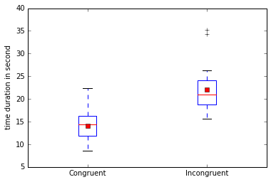

```python
plt.boxplot([x,y],showmeans=True,labels=['Congruent','Incongruent'])
plt.ylabel(" time duration in second")
plt.show()
```

## 5. Now, perform the statistical test and report your results. What is your confidence level and your critical statistic value? Do you reject the null hypothesis or fail to reject it? Come to a conclusion in terms of the experiment task. Did the results match up with your expectations?

```python
ss.ttest_rel(x,y)
```

```
Ttest_relResult(statistic=-8.020706944109957, pvalue=4.1030005857111781e-08)
```